# Apresentação dos Dados e Formulação do Problema

## ❓ A Dúvida:

- A empresa decidiu participar de um novo ranking nacional que medirá quais instituições de ensino melhor preparam seus alunos para o mercado de trabalho.
- É necessário a criação de uma métrica para acompanhar e comparar o desempenho dos alunos participantes e para isso foi realizado um simulado.
- O principal objetivo é avaliar o desempenho e melhora-lo com o investimento de 1MM/semestre.

## 🎲 A Base de Dados:

Para essa missão foi fornecida uma base de dados da matriz curricular da empresa, na qual temos:

1. O resultado (a nota) do simulado por turma, totalizando um pouco mais de 950 mil observações;
2. Mais doze informações como a unidade, curso, e disciplina pertencente a turma em questão;

|  | COD_UNIDADE | DESC_CURSO | COD_MATRIZ | TURNO | N_SEMESTRES | SEMESTRE_ATUAL | Código disciplina | SEMESTRE_OFERTA | ANO_ENTRADA | SEMESTRE_FORMATURA | QTD_ALUNOS | DESEMPENHO_TURMA_PROVA |
| --- | --- | --- | --- | --- | --- | --- | --- | --- | --- | --- | --- | --- |
| 0 | CIL | Administração | ADCS1401 | NOT | 8 | 7 | ATIC001 | 1 | 2014_1 | 2017_2 | 18 | 4 |
| 1 | CIL | Administração | ADCS1401 | NOT | 8 | 7 | CSA1177 | 1 | 2014_1 | 2017_2 | 18 | 4 |
| 2 | CIL | Administração | ADCS1401 | NOT | 8 | 7 | CSA1230 | 1 | 2014_1 | 2017_2 | 18 | 4 |

# 📊 Visualizando os dados

## Distribuição de algumas variáveis

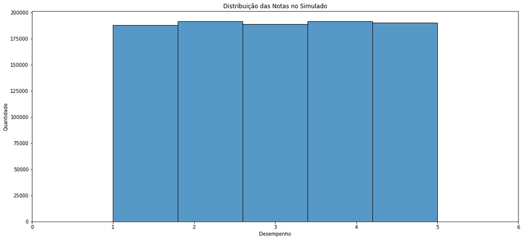

- Podemos observar uma distribuição uniforme, sem tendência clara.
- Estatisticamente quer dizer que qualquer aluno pode tirar qualquer nota 🤷

E se dividirmos as notas por turno? 🔍

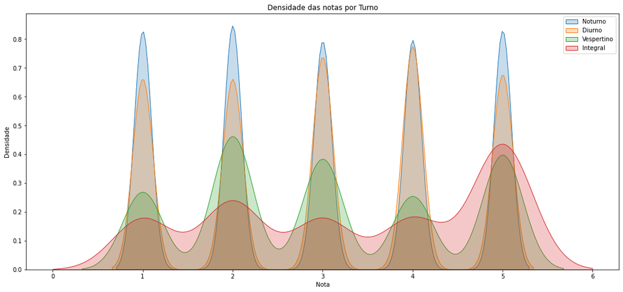

💡 Parece que temos uma tendência!

O problema é que as turmas de período integral são em quantidade ínfima 🤡

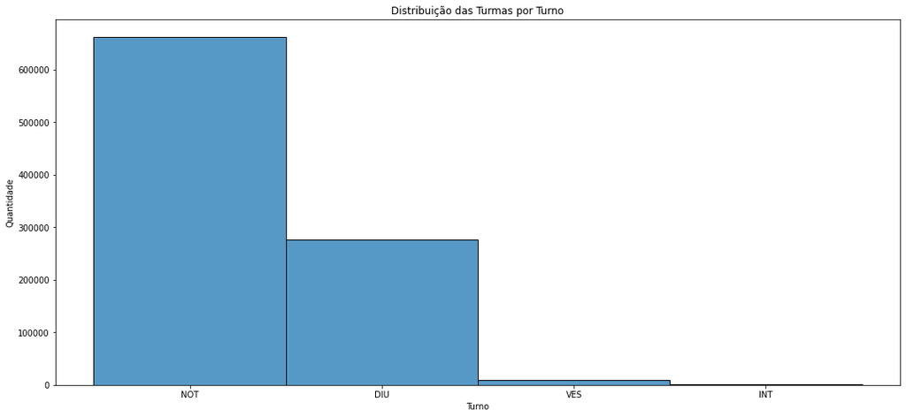

## 🏛️ As unidades que tiveram pior desempenho

Vamos mudar o foco para um espectro mais macro e observar o desempenho de cada unidade

- Cada ponto é uma das 78 unidades presente na base.
- O tamanho é associado a quantidade de disciplinas ofertadas por cada uma.

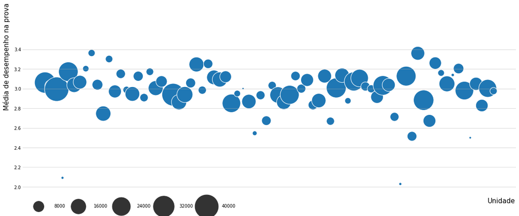

🧐 Conclusões

1. Não há correlação direta;
2. A maioria aparece dentro da média e dentro do desvio padrão;
3. Algumas unidades menores apresentam pior desempenho;

## 📚 Por Cursos

- Uma análise aglutinada pelos cursos, independente da disciplina.
- O tamanho referindo a quantidade de turmas por curso.
- Cada cor é um semestre, observando se há alguma tendência associada.

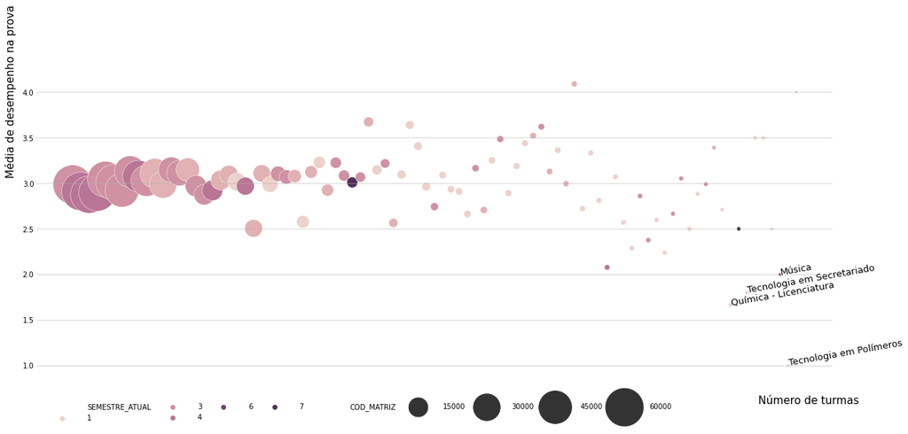

🤓 Conclusões

1. Maior o curso = mais consistente a média (explicável estatisticamente).
2. Correlação que menor o curso, menor a nota (não é causalidade!).
3. Semestre atual não apresenta nenhum efeito.
- Cursos menores estão menos sujeitos ao Teorema Central do Limite.
- Menores cursos estão mais aptos a um salto de qualidade.
- São 26 cursos que se enquadram no 60% com menos turmas e estão abaixo da média na prova
- Um investimento de 38000 por curso.
- Pode ser refinado!

## 🧑‍🎓 Análise Por Turmas

- Seguir a tendência da análise por curso.
- Observar o número de turmas abaixo da média

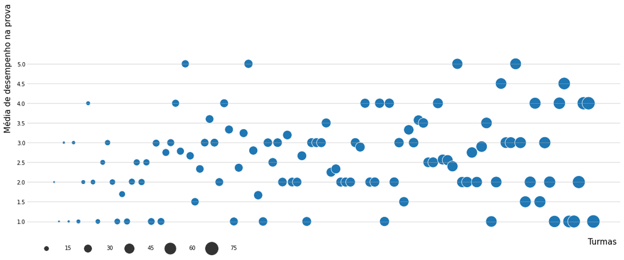

🤔 Conclusões

1. Maior número de turmas na parte inferior da tabela.
2. Confirmando a tendência na análise dos cursos.
3. Possibilidade de listar turmas e direcionar o investimento.

# 📈 Considerações finais

- Observamos a tendência de baixo rendimento nos menores cursos
- Não é causalidade!
- Necessário mais dados.
- A presença de uma série históriaca é fundamental para o planejamento de cada semestre.
- Para o segundo semestre de 2021 é possível fazer um investimento em 27 turmas que ainda estão para se formar.
- Uma divisão de 37 mil para cada, o que é razoável.